# Llega agua de Salvajina

Kenneth Roy Cabrera Torres

Martes, 29 de enero de 2019

## “Así será la ayuda que recibirá Hidroituango de una represa del Cauca”.

En el periódico El Colombiano del día 26 de enero de 2019, en la página 12, bajo el título de “Represa del Cauca liberará agua para el embalse de Hidroituango”, se muestra la siguiente gráfica:

[figure not shown]

La gráfica muestra un aumento lineal de la cota o nivel del embalse, debido a la perspectiva de los rectángulos que representan los valores.

Esta ilusión óptica distorsiona la presentación de los datos, ya que si se grafican a la escala correcta el incremento de los niveles del embalse se va disminuyendo en los últimos días.

## Elementos de un gráfico.

- Título principal.
- Título secundario o subtítulo.
- Descripción del gráfico.
- Región de datos y símbolos.
- Eje horizontal y escala.
- Eje vertical y escala.
- Apuntadores-
- Descriptores de señales y marcas.

## Recomendaciones generales para elaborar un gráfico.

- Haga que sus datos sobresalgan. Evite los superfluo.
- Utilice elementos prominentes para mostrar sus datos.
- Coloque marcas afuera de la región de los datos.
- No apeñuzque la región de datos.
- No exager el número de marcas.
- Utilice una línea de referencia cuando haya un valor importante que deba verse a través de todo el gráfico, pero no deje que interfiera con sus datos.
- Evite colcoar nota, marcas o señales a un lado de la región de datos. Coloque notas en el texto o la explicación.
- Gráficos sobrepuesto deben ser visualmente distinguibles.
- Datos sobrepuestos deben ser visualmente discernibles.
- La claridad visual debe conservarse bajo reducción y reproducción del gráfica.

## Bibliografia.

Correa, Juan Carlos y González Nelfi. Gráficos Estadísticos con R. Universidad Nacional de Colombia-Sede Medellín. 2002. [Enlace en la documentación de R](https://cran.r-project.org/doc/contrib/grafi3.pdf)

## Evolución del nivel del embalse de Hidroituango.

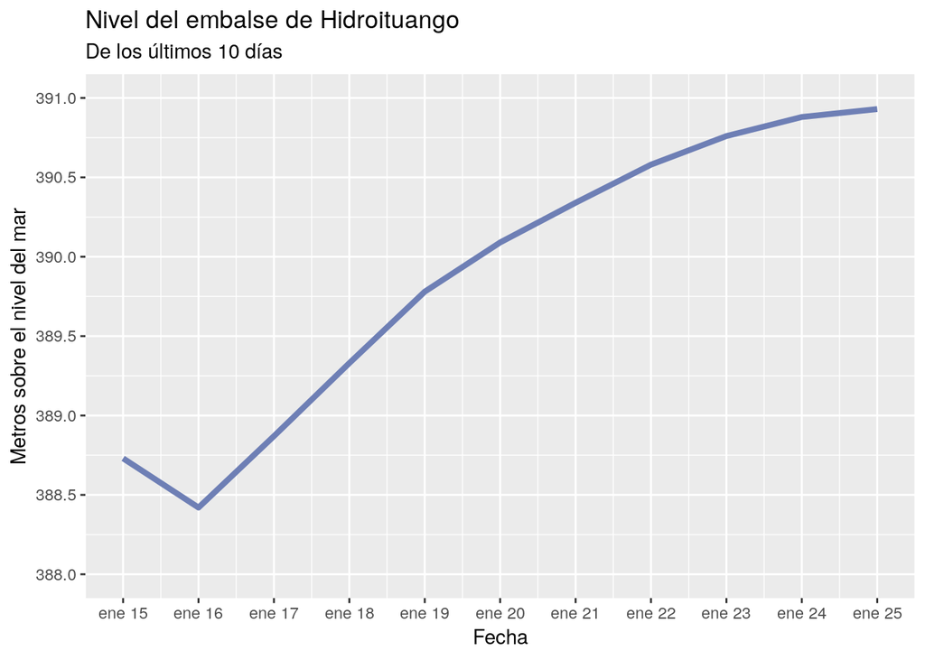

La gráfica muesta ahor que el aumento de la cota no es de manera lineal, ni mantiene constante ese aumento, por el contrario se nota que en los últimos días casi no es significativo el aumento del embalse.

## Gráfica de los caudales entrantes y salientes.

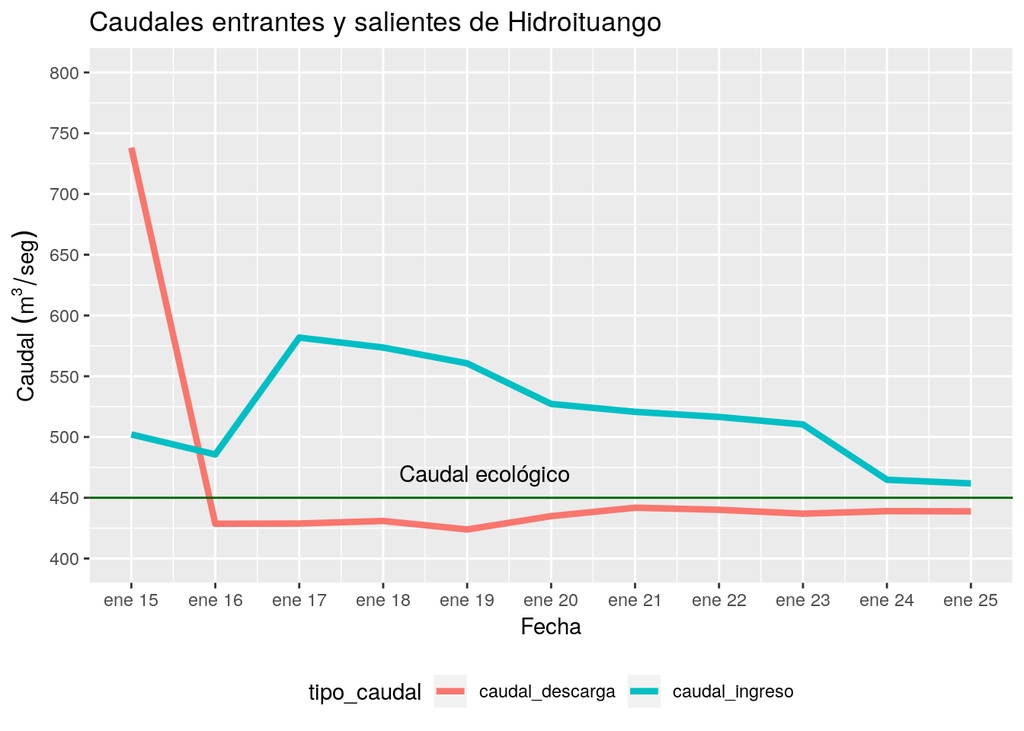

Aunque los diagramas de barras están bien construidos, es más favorable observar las fluctuaciones y comportamientos con el tiempo de los caudales entrantes y salientes y además facilita la comparación de los dos tipos de caudales y explica el comportamiento del nivel o cota del embalse, debido a que el caudal de ingreso ha disminuido con el tiempo, razón por la cual se necesita la ayuda de la represa Salvajina ubidada en el Cauca.

## Comparación de las dos gráficas de nivel de embalse y caudales.

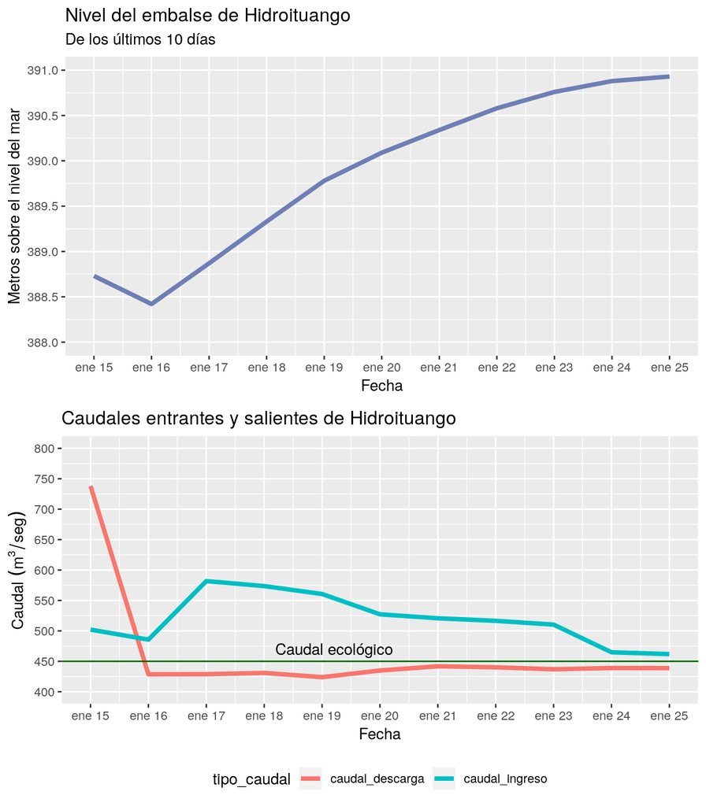

Se compara las dos gráficas de tal manera que se observa la relación entre los comportamientos de los caudales y el nivel o cota del embalse.